# 4.1-Final-Code.R

DiBip

2025-09-04

What: Deletes all objects from your R session. Why: Ensures a clean environment when knitting, so old variables don’t silently affect results.

```r
rm(list = ls())
```

Tells knitr to echo code chunks in the knitted report What: Configures knitr so your code appears in the HTML output. Why: For transparency and grading—your code is visible alongside results.

```r
knitr::opts_chunk$set(echo = TRUE)
```

```r
options(repos = c(CRAN = "https://cloud.r-project.org"))
install.packages("ggplot2", dependencies = TRUE)
```

Set working directory so R knows where to look for the data file What: Changes the working directory. Why: So read.table(“credit_card_data-headers.txt”, …) will find the file.

```r
getwd()
```

```
## [1] "C:/Users/DiBip/Downloads/Georgia Tech/IYSE-6501/Week 2"
```

```r
setwd("~/Week_2")
```

```r
library(ggplot2)

str(iris)
```

```
## 'data.frame':    150 obs. of  5 variables:
##  $ Sepal.Length: num  5.1 4.9 4.7 4.6 5 5.4 4.6 5 4.4 4.9 ...
##  $ Sepal.Width : num  3.5 3 3.2 3.1 3.6 3.9 3.4 3.4 2.9 3.1 ...
##  $ Petal.Length: num  1.4 1.4 1.3 1.5 1.4 1.7 1.4 1.5 1.4 1.5 ...
##  $ Petal.Width : num  0.2 0.2 0.2 0.2 0.2 0.4 0.3 0.2 0.2 0.1 ...
##  $ Species     : Factor w/ 3 levels "setosa","versicolor",..: 1 1 1 1 1 1 1 1 1 1 ...
```

```r
data(iris)
head(iris)
```

```
##   Sepal.Length Sepal.Width Petal.Length Petal.Width Species
## 1          5.1         3.5          1.4         0.2  setosa
## 2          4.9         3.0          1.4         0.2  setosa
## 3          4.7         3.2          1.3         0.2  setosa
## 4          4.6         3.1          1.5         0.2  setosa
## 5          5.0         3.6          1.4         0.2  setosa
## 6          5.4         3.9          1.7         0.4  setosa
```

```r
print(summary(iris))
```

```
##   Sepal.Length    Sepal.Width     Petal.Length    Petal.Width
##  Min.   :4.300   Min.   :2.000   Min.   :1.000   Min.   :0.100
##  1st Qu.:5.100   1st Qu.:2.800   1st Qu.:1.600   1st Qu.:0.300
##  Median :5.800   Median :3.000   Median :4.350   Median :1.300
##  Mean   :5.843   Mean   :3.057   Mean   :3.758   Mean   :1.199
##  3rd Qu.:6.400   3rd Qu.:3.300   3rd Qu.:5.100   3rd Qu.:1.800
##  Max.   :7.900   Max.   :4.400   Max.   :6.900   Max.   :2.500
##        Species
##  setosa    :50
##  versicolor:50
##  virginica :50
##
##
##
```

```r
set.seed(123)
```

This sets variables to be functioned in returning a plot to find efficient number of clusters for this analysis.

```r
"Computes total within-cluster sum of squares (WSS) for k = 1..7.
Why: To make an elbow plot and pick a reasonable k (bend typically near k≈3 for Iris).
nstart = 5 runs multiple random starts and keeps the best; iter.max = 15 caps iterations."
```

```
## [1] "Computes total within-cluster sum of squares (WSS) for k = 1..7.\nWhy: To make an elbow plot and pick a reasonable k (bend typically near k≈3 for Iris).\nnstart = 5 runs multiple random starts and keeps the best; iter.max = 15 caps iterations."
```

tot.withiness mean in k-means each point belongs to the nearest cluster center. The smaller tot.withiness = tighter, denser clusters, and as you increase k, tot.withinss always goes down (because more clusters = smaller distances).

```r
c.max <- 7
data <- as.matrix(iris[,1:4])
samp <- sapply(1:c.max,function(k){kmeans(data,k,nstart=5,iter.max=15)$tot.withinss})
samp
```

```
## [1] 681.37060 152.34795  78.85144  57.22847  46.46117  41.70442  34.29823
```

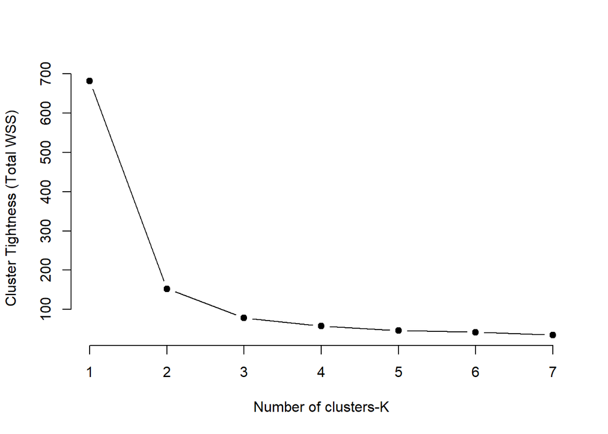

```r
plot(1:c.max, samp,
     type="b", pch = 19, frame = FALSE,
     xlab="Number of clusters-K",
     ylab="Cluster Tightness (Total WSS)")
```

Define km with kmeans which requires you to pick k = numbers of clusters.

1:4 uses all 4 predictors for I will choose to start with 3 clusters based on plot so I set centers = 3. Then have nstart = 20 which runs k-means 20 times with different seeds and keeps the best solution.

```r
km <- kmeans(iris[, 1:4], centers = 3, nstart = 20)
```

This evaluates cluster quality. (unsupervised) This lets me know how many of each species ended up in each cluster.

```r
" The cross tab is comparing the rows <- the clusters found by k-means (km$cluster)
the columns <- the actual known species labels (iris$Species)"
```

```
## [1] " The cross tab is comparing the rows <- the clusters found by k-means (km$cluster)\nthe columns <- the actual known species labels (iris$Species)"
```

```r
table(km$cluster, iris$Species)
```

```
##
##     setosa versicolor virginica
##   1     50          0         0
##   2      0          2        36
##   3      0         48        14
```

```r
"Cluster 1 contains 50 setosa (perfect grouping).
Cluster 2 contains mostly virginica (36) but also 2 misclassified versicolor.
Cluster 3 contains mostly versicolor (48) but 14 virginica mixed in."
```

```
## [1] "Cluster 1 contains 50 setosa (perfect grouping).\nCluster 2 contains mostly virginica (36) but also 2 misclassified versicolor.\nCluster 3 contains mostly versicolor (48) but 14 virginica mixed in."
```

Finding the best predictors

```r
# Only petal predictors
"This set is to compare the petal features of petal length and width"
```

```
## [1] "This set is to compare the petal features of petal length and width"
```

```r
km_petal <- kmeans(iris[,3:4], centers = 3, nstart = 20)
table(km_petal$cluster, iris$Species)
```

```
##
##     setosa versicolor virginica
##   1     50          0         0
##   2      0         48         4
##   3      0          2        46
```

```r
# Only sepal predictors
"This set is to compare sepal features exclusively"
```

```
## [1] "This set is to compare sepal features exclusively"
```

```r
km_sepal <- kmeans(iris[,1:2], centers = 3, nstart = 20)
table(km_sepal$cluster, iris$Species)
```

```
##
##     setosa versicolor virginica
##   1     50          0         0
##   2      0         38        15
##   3      0         12        35
```

This computes the accuracy by majority vote per cluster to determine its efficient attributed cluster.

```r
"apply function uses cm as the matrix, the margin which is 1
because each row = one cluster, and we want the cluster’s 'majority species',
and the max to take the maximum value from each row."
```

```
## [1] "apply function uses cm as the matrix, the margin which is 1 \nbecause each row = one cluster, and we want the cluster’s 'majority species', \nand the max to take the maximum value from each row."
```

```r
cm <- as.matrix(table(km_petal$cluster, iris$Species))
acc <- sum(apply(cm, 1, max)) / sum(cm)
acc   # proportion correctly grouped
```

```
## [1] 0.96
```

This quick plots a visual for the petal features.

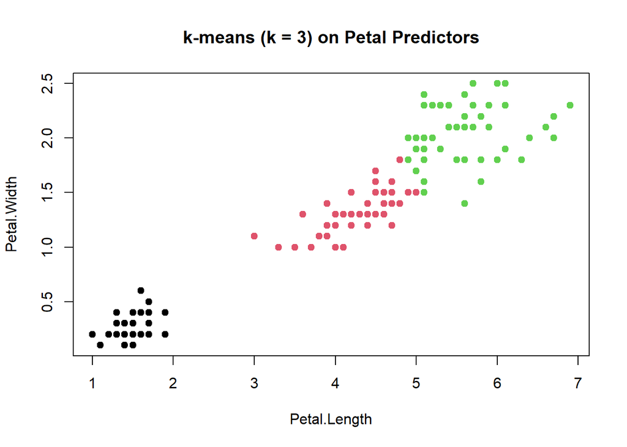

```r
plot(iris[, 3:4],
     col = km_petal$cluster, pch = 19,
     xlab = "Petal.Length", ylab = "Petal.Width",
     main = "k-means (k = 3) on Petal Predictors")
```

This quick plots a visual for the sepal features

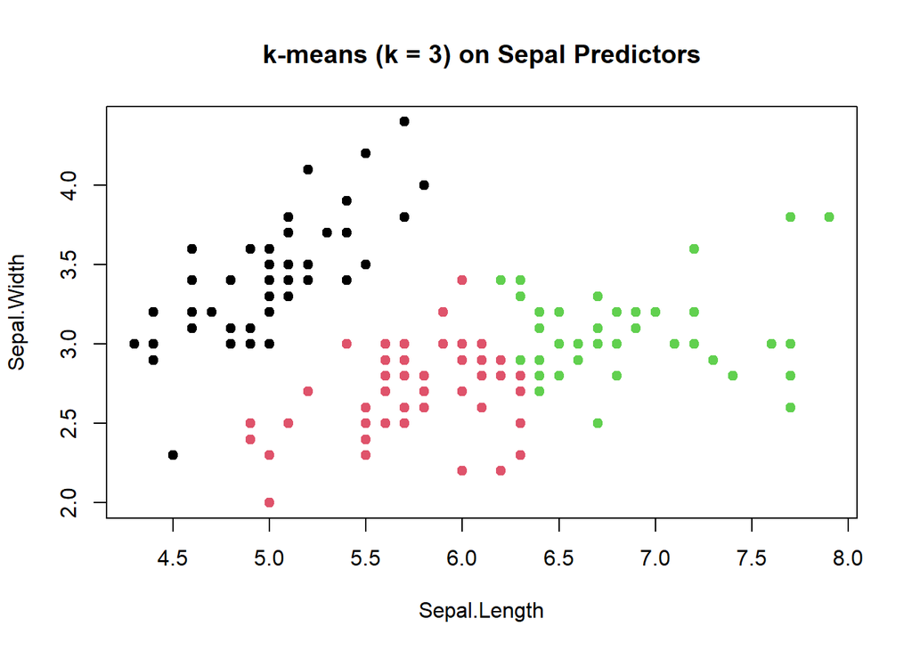

```r
plot(iris[, 1:2],
     col = km_sepal$cluster, pch = 19,
     xlab = "Sepal.Length", ylab = "Sepal.Width",
     main = "k-means (k = 3) on Sepal Predictors")
```

This segment of code below is to compare the accuracies of all the different methods Here I can directly compare predictor sets.

```r
km_all   <- kmeans(iris[, 1:4], centers = 3, nstart = 20)
km_sepal <- kmeans(iris[, 1:2], centers = 3, nstart = 20)

acc_all   <- { cm <- table(km_all$cluster,   iris$Species);   sum(apply(cm, 1, max))/sum(cm) }
acc_sepal <- { cm <- table(km_sepal$cluster, iris$Species);   sum(apply(cm, 1, max))/sum(cm) }

acc_all; acc_sepal; acc   # compare accuracies
```

```
## [1] 0.8933333
```

```
## [1] 0.82
```

```
## [1] 0.96
```

This computes the final table for accuracy for the best in the model based on my findings, the diagonal accuracy is in reference to cluster numbering lining up with that classification of species. Which is does, hence why the rating is of 0.96 for its accuracy.

```r
cm <- table(km_petal$cluster, iris$Species)
accuracy <- sum(diag(cm)) / sum(cm)
accuracy
```

```
## [1] 0.96
```